# Unsupervised Learning: Trade & Ahead

## Problem Statement

### Context

The stock market has consistently proven to be a good place to invest in and save for the future. There are a lot of compelling reasons to invest in stocks. It can help in fighting inflation, create wealth, and also provides some tax benefits. Good steady returns on investments over a long period of time can also grow a lot more than seems possible. Also, thanks to the power of compound interest, the earlier one starts investing, the larger the corpus one can have for retirement. Overall, investing in stocks can help meet life's financial aspirations.

It is important to maintain a diversified portfolio when investing in stocks in order to maximise earnings under any market condition. Having a diversified portfolio tends to yield higher returns and face lower risk by tempering potential losses when the market is down. It is often easy to get lost in a sea of financial metrics to analyze while determining the worth of a stock, and doing the same for a multitude of stocks to identify the right picks for an individual can be a tedious task. By doing a cluster analysis, one can identify stocks that exhibit similar characteristics and ones which exhibit minimum correlation. This will help investors better analyze stocks across different market segments and help protect against risks that could make the portfolio vulnerable to losses.

### Objective

Trade&Ahead is a financial consultancy firm who provide their customers with personalized investment strategies. They have hired you as a Data Scientist and provided you with data comprising stock price and some financial indicators for a few companies listed under the New York Stock Exchange. They have assigned you the tasks of analyzing the data, grouping the stocks based on the attributes provided, and sharing insights about the characteristics of each group.

### Data Dictionary

- Ticker Symbol: An abbreviation used to uniquely identify publicly traded shares of a particular stock on a particular stock market
- Company: Name of the company
- GICS Sector: The specific economic sector assigned to a company by the Global Industry Classification Standard (GICS) that best defines its business operations
- GICS Sub Industry: The specific sub-industry group assigned to a company by the Global Industry Classification Standard (GICS) that best defines its business operations
- Current Price: Current stock price in dollars
- Price Change: Percentage change in the stock price in 13 weeks
- Volatility: Standard deviation of the stock price over the past 13 weeks
- ROE: A measure of financial performance calculated by dividing net income by shareholders' equity (shareholders' equity is equal to a company's assets minus its debt)
- Cash Ratio: The ratio of a company's total reserves of cash and cash equivalents to its total current liabilities
- Net Cash Flow: The difference between a company's cash inflows and outflows (in dollars)
- Net Income: Revenues minus expenses, interest, and taxes (in dollars)
- Earnings Per Share: Company's net profit divided by the number of common shares it has outstanding (in dollars)
- Estimated Shares Outstanding: Company's stock currently held by all its shareholders
- P/E Ratio: Ratio of the company's current stock price to the earnings per share
- P/B Ratio: Ratio of the company's stock price per share by its book value per share (book value of a company is the net difference between that company's total assets and total liabilities)

## Importing necessary libraries and data

```python
# Installing the libraries with the specified version.

!pip install scikit-learn==1.2.2 seaborn==0.13.1 matplotlib==3.7.1 numpy==1.25.2 pandas==1.5.3 yellowbrick==1.5 -q --user
```

[output not shown]

**Note**: *After running the above cell, kindly restart the notebook kernel and run all cells sequentially from the start again.*

```python
from google.colab import drive
drive.mount('/content/drive')
```

```python
#Important Libraries

import pandas as pd
import numpy as np
import matplotlib.pyplot as plt
import seaborn as sns

# To ignore warnings
import warnings
warnings.filterwarnings('ignore')

# Remove the limit from the number of displayed columns and rows.
pd.set_option("display.max_columns", None)
pd.set_option("display.max_rows", None)

df = pd.read_csv("/content/drive/MyDrive/Stock_Project/stock_data.csv")
```

## Data Overview

- Observations
- Sanity checks

```python
df.head()
```

|  | Ticker Symbol | Security | GICS Sector | GICS Sub Industry | Current Price | Price Change | Volatility | ROE | Cash Ratio | Net Cash Flow | Net Income | Earnings Per Share | Estimated Shares Outstanding | P/E Ratio | P/B Ratio |
| --- | --- | --- | --- | --- | --- | --- | --- | --- | --- | --- | --- | --- | --- | --- | --- |
| 0 | AAL | American Airlines Group | Industrials | Airlines | 42.349998 | 9.999995 | 1.687151 | 135 | 51 | -604000000 | 7610000000 | 11.39 | 6.681299e+08 | 3.718174 | -8.784219 |
| 1 | ABBV | AbbVie | Health Care | Pharmaceuticals | 59.240002 | 8.339433 | 2.197887 | 130 | 77 | 51000000 | 5144000000 | 3.15 | 1.633016e+09 | 18.806350 | -8.750068 |
| 2 | ABT | Abbott Laboratories | Health Care | Health Care Equipment | 44.910000 | 11.301121 | 1.273646 | 21 | 67 | 938000000 | 4423000000 | 2.94 | 1.504422e+09 | 15.275510 | -0.394171 |
| 3 | ADBE | Adobe Systems Inc | Information Technology | Application Software | 93.940002 | 13.977195 | 1.357679 | 9 | 180 | -240840000 | 629551000 | 1.26 | 4.996437e+08 | 74.555557 | 4.199651 |
| 4 | ADI | Analog Devices, Inc. | Information Technology | Semiconductors | 55.320000 | -1.827858 | 1.701169 | 14 | 272 | 315120000 | 696878000 | 0.31 | 2.247994e+09 | 178.451613 | 1.059810 |

```python
df.info()
```

```
<class 'pandas.core.frame.DataFrame'>
RangeIndex: 340 entries, 0 to 339
Data columns (total 15 columns):
 #   Column                        Non-Null Count  Dtype
---  ------                        --------------  -----
 0   Ticker Symbol                 340 non-null    object
 1   Security                      340 non-null    object
 2   GICS Sector                   340 non-null    object
 3   GICS Sub Industry             340 non-null    object
 4   Current Price                 340 non-null    float64
 5   Price Change                  340 non-null    float64
 6   Volatility                    340 non-null    float64
 7   ROE                           340 non-null    int64
 8   Cash Ratio                    340 non-null    int64
 9   Net Cash Flow                 340 non-null    int64
 10  Net Income                    340 non-null    int64
 11  Earnings Per Share            340 non-null    float64
 12  Estimated Shares Outstanding  340 non-null    float64
 13  P/E Ratio                     340 non-null    float64
 14  P/B Ratio                     340 non-null    float64
dtypes: float64(7), int64(4), object(4)
memory usage: 40.0+ KB
```

```python
#summary stats
df.describe()
```

|  | Current Price | Price Change | Volatility | ROE | Cash Ratio | Net Cash Flow | Net Income | Earnings Per Share | Estimated Shares Outstanding | P/E Ratio | P/B Ratio |
| --- | --- | --- | --- | --- | --- | --- | --- | --- | --- | --- | --- |
| count | 340.000000 | 340.000000 | 340.000000 | 340.000000 | 340.000000 | 3.400000e+02 | 3.400000e+02 | 340.000000 | 3.400000e+02 | 340.000000 | 340.000000 |
| mean | 80.862345 | 4.078194 | 1.525976 | 39.597059 | 70.023529 | 5.553762e+07 | 1.494385e+09 | 2.776662 | 5.770283e+08 | 32.612563 | -1.718249 |
| std | 98.055086 | 12.006338 | 0.591798 | 96.547538 | 90.421331 | 1.946365e+09 | 3.940150e+09 | 6.587779 | 8.458496e+08 | 44.348731 | 13.966912 |
| min | 4.500000 | -47.129693 | 0.733163 | 1.000000 | 0.000000 | -1.120800e+10 | -2.352800e+10 | -61.200000 | 2.767216e+07 | 2.935451 | -76.119077 |
| 25% | 38.555000 | -0.939484 | 1.134878 | 9.750000 | 18.000000 | -1.939065e+08 | 3.523012e+08 | 1.557500 | 1.588482e+08 | 15.044653 | -4.352056 |
| 50% | 59.705000 | 4.819505 | 1.385593 | 15.000000 | 47.000000 | 2.098000e+06 | 7.073360e+08 | 2.895000 | 3.096751e+08 | 20.819876 | -1.067170 |
| 75% | 92.880001 | 10.695493 | 1.695549 | 27.000000 | 99.000000 | 1.698108e+08 | 1.899000e+09 | 4.620000 | 5.731175e+08 | 31.764755 | 3.917066 |
| max | 1274.949951 | 55.051683 | 4.580042 | 917.000000 | 958.000000 | 2.076400e+10 | 2.444200e+10 | 50.090000 | 6.159292e+09 | 528.039074 | 129.064585 |

```python
#checking for nulls
df.isnull().sum()
```

|  | 0 |
| --- | --- |
| Ticker Symbol | 0 |
| Security | 0 |
| GICS Sector | 0 |
| GICS Sub Industry | 0 |
| Current Price | 0 |
| Price Change | 0 |
| Volatility | 0 |
| ROE | 0 |
| Cash Ratio | 0 |
| Net Cash Flow | 0 |
| Net Income | 0 |
| Earnings Per Share | 0 |
| Estimated Shares Outstanding | 0 |
| P/E Ratio | 0 |
| P/B Ratio | 0 |

**dtype:** int64

```python
#checking for duplicates
df.duplicated().sum()
```

```
np.int64(0)
```

```python
#checking that certain values are unique
df['Ticker Symbol'].nunique()
```

```
340
```

```python
#checking for unique sub industries
df['GICS Sub Industry'].value_counts()
```

| GICS Sub Industry | count |
| --- | --- |
| Oil & Gas Exploration & Production | 16 |
| REITs | 14 |
| Industrial Conglomerates | 14 |
| Electric Utilities | 12 |
| Internet Software & Services | 12 |
| Health Care Equipment | 11 |
| MultiUtilities | 11 |
| Banks | 10 |
| Property & Casualty Insurance | 8 |
| Biotechnology | 7 |
| Diversified Financial Services | 7 |
| Semiconductors | 6 |
| Oil & Gas Refining & Marketing & Transportation | 6 |
| Packaged Foods & Meats | 6 |
| Pharmaceuticals | 6 |
| Airlines | 5 |
| Diversified Chemicals | 5 |
| Health Care Facilities | 5 |
| Integrated Oil & Gas | 5 |
| Industrial Machinery | 5 |
| Managed Health Care | 5 |
| Consumer Finance | 5 |
| Aerospace & Defense | 4 |
| Hotels, Resorts & Cruise Lines | 4 |
| Asset Management & Custody Banks | 4 |
| Specialty Chemicals | 4 |
| Building Products | 4 |
| Railroads | 4 |
| Integrated Telecommunications Services | 4 |
| Research & Consulting Services | 4 |

[output cut: 74 more lines]

**dtype:** int64

```python
#checking for unique sectors
df['GICS Sector'].value_counts()
```

| GICS Sector | count |
| --- | --- |
| Industrials | 53 |
| Financials | 49 |
| Health Care | 40 |
| Consumer Discretionary | 40 |
| Information Technology | 33 |
| Energy | 30 |
| Real Estate | 27 |
| Utilities | 24 |
| Materials | 20 |
| Consumer Staples | 19 |
| Telecommunications Services | 5 |

**dtype:** int64

```python
#outlier detection on price
Q1 = df['Current Price'].quantile(0.25)
Q3 = df['Current Price'].quantile(0.75)
IQR = Q3 - Q1

lower_bound = Q1 - 1.5 * IQR
upper_bound = Q3 + 1.5 * IQR

outliers = df[(df['Current Price'] < lower_bound) | (df['Current Price'] > upper_bound)]
print(outliers)
```

```
    Ticker Symbol                     Security             GICS Sector  \
6             ADS        Alliance Data Systems  Information Technology
19           ALXN      Alexion Pharmaceuticals             Health Care
26           AMZN               Amazon.com Inc  Consumer Discretionary
35            AVB  AvalonBay Communities, Inc.             Real Estate
43            BCR             Bard (C.R.) Inc.             Health Care
45           BIIB             BIOGEN IDEC Inc.             Health Care
64           CHTR       Charter Communications  Consumer Discretionary
70            CMG       Chipotle Mexican Grill  Consumer Discretionary
110          EQIX                      Equinix             Real Estate
114           ESS   Essex Property Trust, Inc.             Real Estate
146           GWW         Grainger (W.W.) Inc.             Industrials
163           HUM                  Humana Inc.             Health Care
171          ISRG      Intuitive Surgical Inc.             Health Care
189           LMT        Lockheed Martin Corp.             Industrials
```

[output cut: 80 more lines]

```python
#outlier detection on P/E
Q1 = df['P/E Ratio'].quantile(0.25)
Q3 = df['P/E Ratio'].quantile(0.75)
IQR = Q3 - Q1

lower_bound = Q1 - 1.5 * IQR
upper_bound = Q3 + 1.5 * IQR

outliers = df[(df['P/E Ratio'] < lower_bound) | (df['P/E Ratio'] > upper_bound)]
print(outliers)
```

```
    Ticker Symbol                     Security             GICS Sector  \
3            ADBE            Adobe Systems Inc  Information Technology
4             ADI         Analog Devices, Inc.  Information Technology
19           ALXN      Alexion Pharmaceuticals             Health Care
25            AMT        American Tower Corp A             Real Estate
26           AMZN               Amazon.com Inc  Consumer Discretionary
30            APA           Apache Corporation                  Energy
31            APC      Anadarko Petroleum Corp                  Energy
43            BCR             Bard (C.R.) Inc.             Health Care
44            BHI             Baker Hughes Inc                  Energy
48            BMY         Bristol-Myers Squibb             Health Care
58           CELG                Celgene Corp.             Health Care
76            COG              Cabot Oil & Gas                  Energy
84            CXO             Concho Resources                  Energy
102           DVN           Devon Energy Corp.                  Energy
```

[output cut: 156 more lines]

## Exploratory Data Analysis (EDA)

- EDA is an important part of any project involving data.
- It is important to investigate and understand the data better before building a model with it.
- A few questions have been mentioned below which will help you approach the analysis in the right manner and generate insights from the data.
- A thorough analysis of the data, in addition to the questions mentioned below, should be done.

**Questions**:

1. What does the distribution of stock prices look like?
2. The stocks of which economic sector have seen the maximum price increase on average?
3. How are the different variables correlated with each other?
4. Cash ratio provides a measure of a company's ability to cover its short-term obligations using only cash and cash equivalents. How does the average cash ratio vary across economic sectors?
5. P/E ratios can help determine the relative value of a company's shares as they signify the amount of money an investor is willing to invest in a single share of a company per dollar of its earnings. How does the P/E ratio vary, on average, across economic sectors?

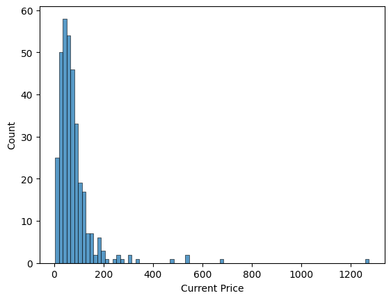

```python
#checking distribution of stock prices
sns.histplot(df['Current Price'])
plt.show()
```

```python
#Finding sector that has seen maximum price increase on average
df.groupby('GICS Sector')['Current Price'].mean().sort_values(ascending=False)
```

| GICS Sector | Current Price |
| --- | --- |
| Health Care | 132.048250 |
| Consumer Discretionary | 128.095404 |
| Real Estate | 90.976925 |
| Materials | 76.551501 |
| Industrials | 74.411807 |
| Consumer Staples | 71.972807 |
| Information Technology | 63.548485 |
| Financials | 58.659183 |
| Utilities | 52.968542 |
| Energy | 46.042334 |
| Telecommunications Services | 32.964000 |

**dtype:** float64

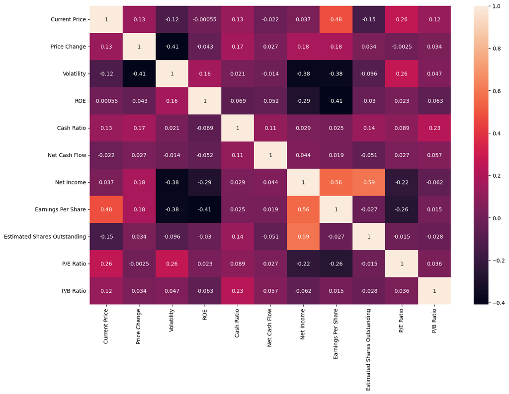

```python
#checking for correlation between variables
plt.figure(figsize=(15,10))
sns.heatmap(df.select_dtypes(include=np.number).corr(),annot=True)
plt.show()
```

```python
#Seeing how average cash ratio varies per sector
df.groupby('GICS Sector')['Cash Ratio'].mean().sort_values(ascending=False)
```

| GICS Sector | Cash Ratio |
| --- | --- |
| Information Technology | 149.818182 |
| Telecommunications Services | 117.000000 |
| Health Care | 103.775000 |
| Financials | 98.591837 |
| Consumer Staples | 70.947368 |
| Energy | 51.133333 |
| Real Estate | 50.111111 |
| Consumer Discretionary | 49.575000 |
| Materials | 41.700000 |
| Industrials | 36.188679 |
| Utilities | 13.625000 |

**dtype:** float64

```python
#Seeing how average P/E ratios vary across sectors?
df.groupby('GICS Sector')['P/E Ratio'].mean().sort_values(ascending=False)
```

| GICS Sector | P/E Ratio |
| --- | --- |
| Energy | 72.897709 |
| Information Technology | 43.782546 |
| Real Estate | 43.065585 |
| Health Care | 41.135272 |
| Consumer Discretionary | 35.211613 |
| Consumer Staples | 25.521195 |
| Materials | 24.585352 |
| Utilities | 18.719412 |
| Industrials | 18.259380 |
| Financials | 16.023151 |
| Telecommunications Services | 12.222578 |

**dtype:** float64

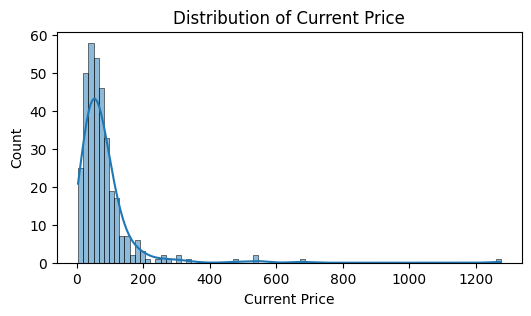

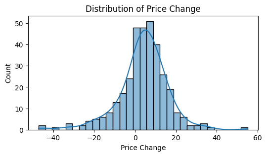

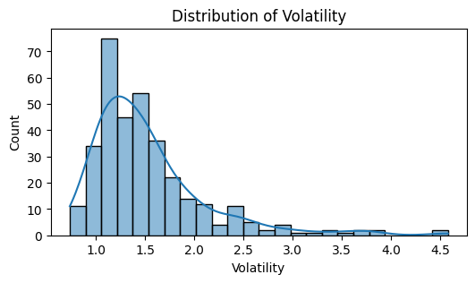

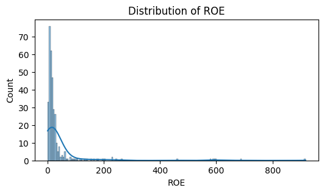

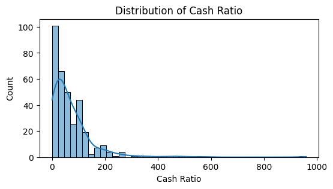

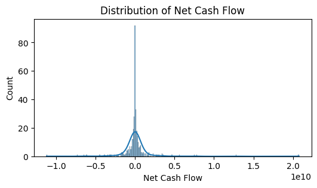

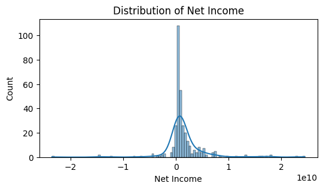

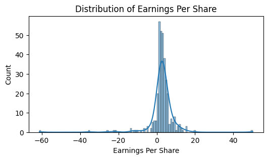

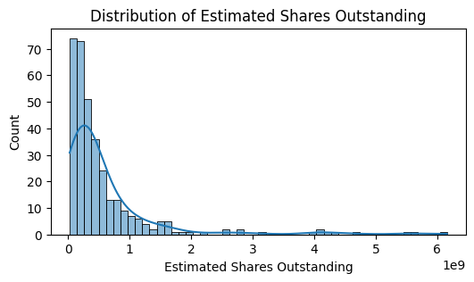

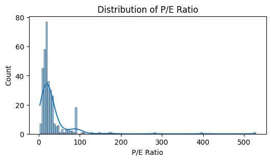

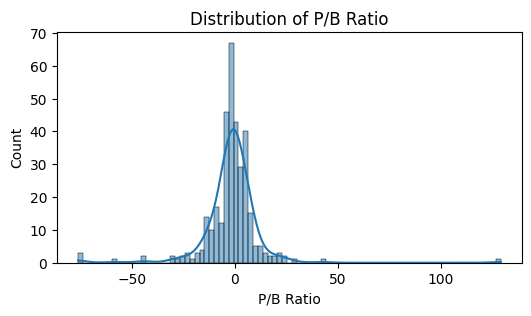

```python
#plotting distribution of the numeric cols

numeric_cols = ['Current Price', 'Price Change', 'Volatility', 'ROE', 'Cash Ratio',
                'Net Cash Flow', 'Net Income', 'Earnings Per Share',
                'Estimated Shares Outstanding', 'P/E Ratio', 'P/B Ratio']

for col in numeric_cols:
    plt.figure(figsize=(6, 3))
    sns.histplot(df[col].dropna(), kde=True)
    plt.title(f'Distribution of {col}')
    plt.show()
```

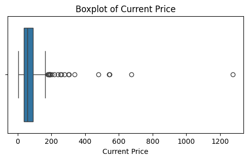

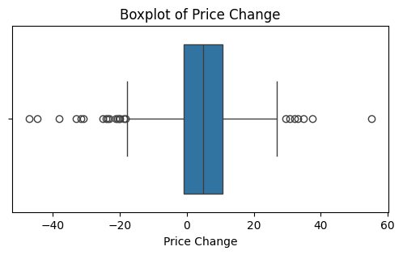

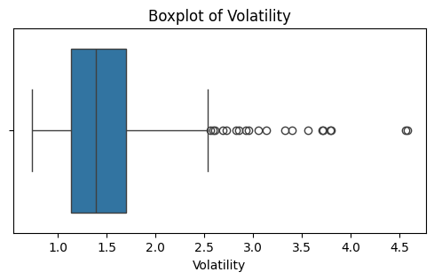

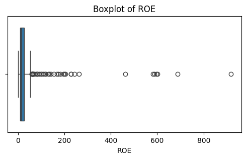

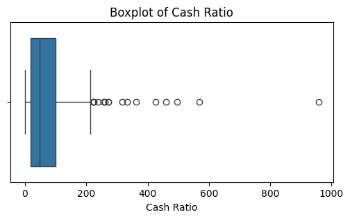

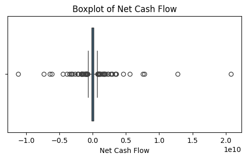

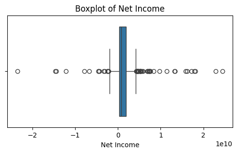

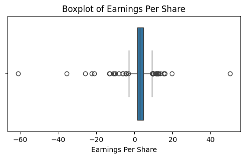

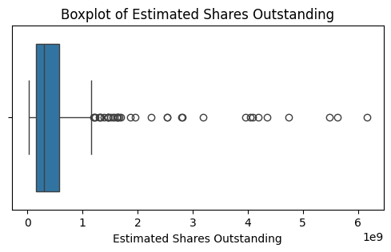

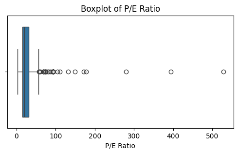

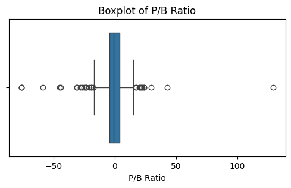

```python
#plotting outliers on the numeric cols
for col in numeric_cols:
    plt.figure(figsize=(6, 3))
    sns.boxplot(x=df[col])
    plt.title(f'Boxplot of {col}')
    plt.show()
```

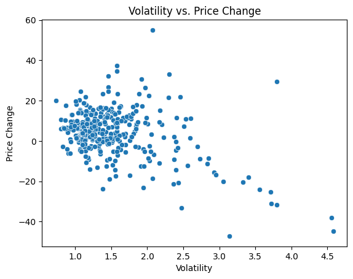

```python
#seeing how volatility and price change interact
sns.scatterplot(x='Volatility', y='Price Change', data=df)
plt.title('Volatility vs. Price Change')
plt.show()
```

## Data Preprocessing

- Duplicate value check
- Missing value treatment
- Outlier check
- Feature engineering (if needed)
- Any other preprocessing steps (if needed)

```python
#Engineering a Market Cap Feature
df['Market Cap'] = df['Current Price'] * df['Estimated Shares Outstanding']
```

```python
#one-hotencoding categorical data
from sklearn.preprocessing import OneHotEncoder

encoder = OneHotEncoder(sparse_output=False)
encoded = encoder.fit_transform(df[['GICS Sector', 'GICS Sub Industry']])
encoded_df = pd.DataFrame(encoded, columns=encoder.get_feature_names_out())
df = pd.concat([df, encoded_df], axis=1).drop(['GICS Sector', 'GICS Sub Industry'], axis=1)
```

```python
#Standardizing cols
from sklearn.preprocessing import StandardScaler

scaler = StandardScaler()
scaled_cols = ['Current Price', 'Price Change', 'Volatility', 'ROE', 'Cash Ratio',
               'Net Cash Flow', 'Net Income', 'Earnings Per Share',
               'Estimated Shares Outstanding', 'P/E Ratio', 'P/B Ratio']
df[scaled_cols] = scaler.fit_transform(df[scaled_cols])
```

```python
#handling outliers

z_scores = np.abs((df[scaled_cols] - df[scaled_cols].mean()) / df[scaled_cols].std())
df = df[(z_scores < 3).all(axis=1)]  # Remove rows with z-score > 3
```